# Week_7_Ch_8_Exercises

```python
import pandas as pd
import plotly.express as px
import plotly.graph_objects as go
from plotly.subplots import make_subplots
import pypandoc
import matplotlib.pyplot as plt
import numpy as np
import statsmodels.api as sm
from sklearn import linear_model

import random

import matplotlib.pyplot as plt
from matplotlib import rcParams
import pandas as pd
import statsmodels.api as sm
import statsmodels.formula.api as smf
from statsmodels.nonparametric.smoothers_lowess import lowess
import numpy as np
import scipy.stats as stats

from sklearn.model_selection import train_test_split
from sklearn.metrics import confusion_matrix
from sklearn.metrics import accuracy_score
from sklearn.metrics import classification_report
from sklearn.metrics import mean_squared_error

from sklearn.linear_model import Ridge
from sklearn.model_selection import cross_val_score
from sklearn import linear_model

from sklearn.decomposition import PCA
from sklearn.model_selection import cross_val_score
from sklearn.preprocessing import StandardScaler
from sklearn.linear_model import LinearRegression
from sklearn.linear_model import LassoCV
from sklearn.linear_model import Lasso
from sklearn.linear_model import RidgeCV
```

```python
from sklearn import tree
from sklearn.tree import DecisionTreeClassifier
from sklearn.tree import DecisionTreeRegressor
```

```python
import graphviz
```

```python
from sklearn.ensemble import RandomForestClassifier
from sklearn.datasets import make_classification
from sklearn.ensemble import RandomForestRegressor
from sklearn.ensemble import GradientBoostingRegressor
```

# Lab 8.3.3 Bagging and Random Forests

```python
Boston = pd.read_csv("Boston.csv", index_col=0)
```

```python
boston_input_cols = list(Boston.columns)
boston_input_cols.remove('medv')
```

```python
X = Boston[boston_input_cols]
y = Boston['medv']
```

```python
# Split into Test and Training data
X_train, X_test, y_train, y_test = train_test_split(X, y, test_size=0.5, random_state=42)
```

```python
clf_bagging = RandomForestRegressor(max_leaf_nodes = 10,
                                     random_state=0, max_features = len(X.columns))
```

```python
clf_bagging = clf_bagging.fit(X_train,y_train)
```

```python
test_predictions = clf_bagging.predict(X_test)
```

```python
mean_squared_error(y_test,test_predictions)
```

```
17.101897037531845
```

Using a bagging approach using all predictors gives an MSE value of 17.1.

```python
clf_rf = RandomForestRegressor(max_leaf_nodes = 10,
                                     random_state=0, max_features = 6)
```

```python
clf_rf = clf_rf.fit(X_train,y_train)
```

```python
test_predictions = clf_rf.predict(X_test)
```

```python
mean_squared_error(y_test,test_predictions)
```

```
15.818883760129776
```

Using a random forest approach with 6 predictors gave a slight improvement to an MSE of 15.8.

```python
clf_rf.feature_importances_
```

```
array([0.04085973, 0.00124461, 0.04201506, 0.00764849, 0.02496697,
       0.3934258 , 0.00980343, 0.04541072, 0.00292295, 0.03426027,
       0.0615122 , 0.00821259, 0.32771719])
```

```
(0.0, 13.0)
```

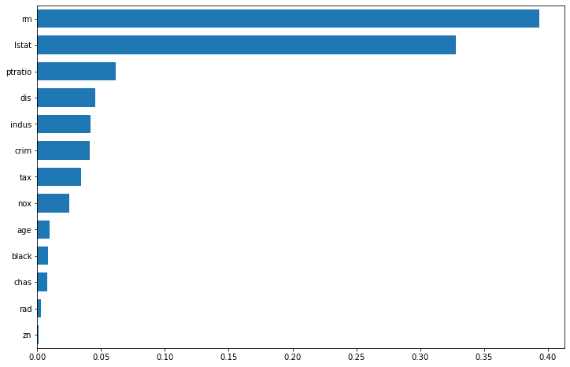

```python
tree_importance_sorted_idx = np.argsort(clf_rf.feature_importances_)
tree_indices = np.arange(0, len(clf_rf.feature_importances_)) + 0.5

fig, ax1 = plt.subplots(1, 1, figsize=(12, 8))
ax1.barh(tree_indices,
         clf_rf.feature_importances_[tree_importance_sorted_idx], height=0.7)
ax1.set_yticklabels(X.columns[tree_importance_sorted_idx])
ax1.set_yticks(tree_indices)
ax1.set_ylim((0, len(clf_rf.feature_importances_)))
```

rm and lstat are the most important features in the random forest model, while rad and zn are the least important.

# Lab 8.3.4 Boosting

```python
clf_boosting = GradientBoostingRegressor(max_leaf_nodes = 10, max_depth=4,
                                     random_state=0,
                                  n_estimators=5000)
```

```python
clf_boosting = clf_boosting.fit(X_train,y_train)
```

```python
test_predictions = clf_boosting.predict(X_test)
```

```python
mean_squared_error(y_test,test_predictions)
```

```
13.837570662877205
```

Using a boosting approach gave a slight improvement to an MSE of 13.83.

```python
clf_boosting = GradientBoostingRegressor(max_leaf_nodes = 10, max_depth=4,
                                     random_state=0,
                                  n_estimators=5000, learning_rate=0.2)
```

```python
clf_boosting = clf_boosting.fit(X_train,y_train)
```

```python
test_predictions = clf_boosting.predict(X_test)
```

```python
mean_squared_error(y_test,test_predictions)
```

```
13.20899192679593
```

Using a boosting approach with a learning rate of 0.2 gave a slight improvement to an MSE of 13.2.

```python
clf_boosting.feature_importances_
```

```
array([2.82147639e-02, 1.95156093e-04, 6.40583452e-03, 1.79940462e-04,
       5.81831632e-03, 5.54775492e-01, 2.03559647e-02, 6.89229019e-02,
       4.64472524e-03, 8.92691416e-03, 2.14830825e-02, 9.07672082e-03,
       2.71000188e-01])
```

```
(0.0, 13.0)
```

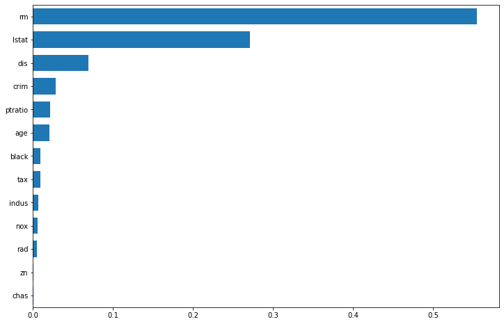

```python
tree_importance_sorted_idx = np.argsort(clf_boosting.feature_importances_)
tree_indices = np.arange(0, len(clf_boosting.feature_importances_)) + 0.5

fig, ax1 = plt.subplots(1, 1, figsize=(12, 8))
ax1.barh(tree_indices,
         clf_boosting.feature_importances_[tree_importance_sorted_idx], height=0.7)
ax1.set_yticklabels(X.columns[tree_importance_sorted_idx])
ax1.set_yticks(tree_indices)
ax1.set_ylim((0, len(clf_boosting.feature_importances_)))
```

rm and lstat are still the most important features in the boosting model, however rm appears to be more important in the boosting model than the random forest. zn and chas are not important at all to the boosting model.

# Problem 9

```python
OJ = pd.read_csv('OJ.csv')
```

```python
OJ['Store7'] = OJ.Store7.map(dict(Yes=1, No=0))
```

```python
oj_input_cols = list(OJ.columns)
oj_input_cols.remove('Purchase')
```

```python
X = OJ[oj_input_cols]
y = OJ['Purchase']
```

```python
# Split into Test and Training data
X_train, X_test, y_train, y_test = train_test_split(X, y, train_size=800, random_state=42)
```

```python
clf = tree.DecisionTreeClassifier(max_leaf_nodes = 10,
                                     random_state=0,)
clf = clf.fit(X_train,y_train)
```

```python
train_predictions = clf.predict(X_train)
```

```python
train_error_rate = 1-accuracy_score(y_train,train_predictions)
train_error_rate
```

```
0.13875000000000004
```

```python
test_predictions = clf.predict(X_test)
```

```python
print(classification_report(y_test,test_predictions))
```

```
              precision    recall  f1-score   support

          CH       0.78      0.82      0.80       159
          MM       0.72      0.67      0.69       111

    accuracy                           0.76       270
   macro avg       0.75      0.74      0.74       270
weighted avg       0.75      0.76      0.75       270
```

```python
error_rate = 1-accuracy_score(y_test,test_predictions)
error_rate
```

```
0.24444444444444446
```

```python
path = clf.cost_complexity_pruning_path(X_train,y_train)
ccp_alphas, impurities = path.ccp_alphas, path.impurities
```

```python
ccp_alphas
```

```
array([0.        , 0.004     , 0.00400962, 0.00659735, 0.00677871,
       0.01385073, 0.01872105, 0.02223619, 0.16926609])
```

```python
tree_size = range(2,11)
```

```python
def run_cross_validation_tree_size(X, y, tree_size, cv=5, scoring='accuracy'):
    cv_scores_list = []
    cv_scores_std = []
    cv_scores_mean = []
    accuracy_scores = []
    for size in tree_size:
        tree_model = DecisionTreeClassifier(random_state=0, max_leaf_nodes=size)
        cv_scores = cross_val_score(tree_model, X, y, cv=cv, scoring=scoring)
        cv_scores_list.append(cv_scores)
        cv_scores_mean.append(cv_scores.mean())
        cv_scores_std.append(cv_scores.std())
        accuracy_scores.append(tree_model.fit(X, y).score(X, y))
    cv_scores_mean = np.array(cv_scores_mean)
    cv_scores_std = np.array(cv_scores_std)
    accuracy_scores = np.array(accuracy_scores)
    return cv_scores_mean, cv_scores_std, accuracy_scores
```

```python
def plot_cross_validation_on_trees(tree_size, cv_scores_mean, cv_scores_std, accuracy_scores, title):
    fig, ax = plt.subplots(1,1, figsize=(15,5))
    ax.plot(tree_size, cv_scores_mean, '-o', label='mean cross-validation accuracy', alpha=0.9)
#     ax.fill_between(ccp_alphas, cv_scores_mean-2*cv_scores_std, cv_scores_mean+2*cv_scores_std, alpha=0.2)
#     ylim = plt.ylim()
    ax.plot(tree_size, accuracy_scores, '-*', label='train accuracy', alpha=0.9)
    ax.set_title(title, fontsize=16)
    ax.set_xlabel('Terminal Nodes', fontsize=14)
    ax.set_ylabel('Accuracy', fontsize=14)
#     ax.set_ylim(ylim)
#     ax.set_xticks(ccp_alphas)
    ax.legend()
```

```python
sm_cv_scores_mean, sm_cv_scores_std, sm_accuracy_scores = run_cross_validation_tree_size(X_train, y_train, tree_size)
```

## Problem 9g) Produce a plot with tree size on x-axis and cross-validated classification error rate on the y-axis

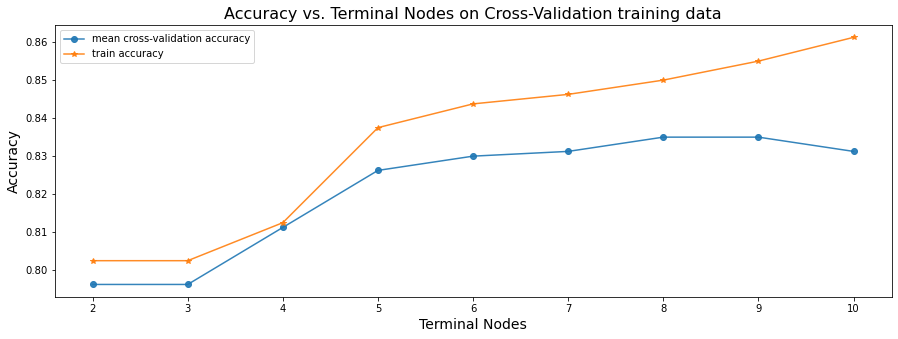

```python
plot_cross_validation_on_trees(tree_size, sm_cv_scores_mean, sm_cv_scores_std, sm_accuracy_scores,
                               'Accuracy vs. Terminal Nodes on Cross-Validation training data')
```

## 9h) Which tree size corresponds to the lowest cross-validated classification error rate?

A tree with 8 terminal nodes shows the lowest cross validtion error rate.

## 9i) Produce pruned tree corresponding to optimal tree size

```python
clf = tree.DecisionTreeClassifier(max_leaf_nodes = 8,
                                     random_state=0,)
clf = clf.fit(X_train,y_train)
```

```python
train_predictions = clf.predict(X_train)
print(classification_report(y_train,train_predictions))
```

```
              precision    recall  f1-score   support

          CH       0.85      0.91      0.88       494
          MM       0.84      0.75      0.79       306

    accuracy                           0.85       800
   macro avg       0.85      0.83      0.84       800
weighted avg       0.85      0.85      0.85       800
```

```python
train_predictions = clf.predict(X_train)
```

```python
train_error_rate = 1-accuracy_score(y_train,train_predictions)
train_error_rate
```

```
0.15000000000000002
```

```python
test_predictions = clf.predict(X_test)
```

```python
print(classification_report(y_test,test_predictions))
```

```
              precision    recall  f1-score   support

          CH       0.77      0.90      0.83       159
          MM       0.81      0.62      0.70       111

    accuracy                           0.79       270
   macro avg       0.79      0.76      0.77       270
weighted avg       0.79      0.79      0.78       270
```

```python
error_rate = 1-accuracy_score(y_test,test_predictions)
error_rate
```

```
0.2148148148148148
```

```python
dot_data = tree.export_graphviz(clf, out_file=None,
                               feature_names=X.columns,
                               class_names=y.unique(),
                               filled=True, rounded=True,
                               special_characters=True)
graph = graphviz.Source(dot_data)
graph
```

[figure not shown]

## Problem 9j) Compare training error rates between pruned and unpruned trees

The error rate on an unpruned tree was 0.14, while the pruned 8 terminal node tree was 0.15 for training data. The unpruned tree has a lower error rate.

## Problem 9k) Compare the test error rates between the pruned and unpruned trees

The error rate on the test data for an unpruned tree was 0.24, while the error rate on the test data for the pruned tree was 0.21. The error rate for test data is lower for the pruned tree.

## Problem 10)

## 10a) Remove observations for whom salary information is unknown and then log-transform the salaries

```python
pd.options.display.max_columns = None
```

```python
Hitters = pd.read_csv("Hitters.csv")
```

```python
Hitters = Hitters.dropna(subset=['Salary'])
```

```python
Hitters['Salary_log'] = np.log(Hitters['Salary'])
```

```python
Hitters.head()
```

|  | AtBat | Hits | HmRun | Runs | RBI | Walks | Years | CAtBat | CHits | CHmRun | CRuns | CRBI | CWalks | League | Division | PutOuts | Assists | Errors | Salary | NewLeague | Salary_log |
| --- | --- | --- | --- | --- | --- | --- | --- | --- | --- | --- | --- | --- | --- | --- | --- | --- | --- | --- | --- | --- | --- |
| 1 | 315 | 81 | 7 | 24 | 38 | 39 | 14 | 3449 | 835 | 69 | 321 | 414 | 375 | N | W | 632 | 43 | 10 | 475.0 | N | 6.163315 |
| 2 | 479 | 130 | 18 | 66 | 72 | 76 | 3 | 1624 | 457 | 63 | 224 | 266 | 263 | A | W | 880 | 82 | 14 | 480.0 | A | 6.173786 |
| 3 | 496 | 141 | 20 | 65 | 78 | 37 | 11 | 5628 | 1575 | 225 | 828 | 838 | 354 | N | E | 200 | 11 | 3 | 500.0 | N | 6.214608 |
| 4 | 321 | 87 | 10 | 39 | 42 | 30 | 2 | 396 | 101 | 12 | 48 | 46 | 33 | N | E | 805 | 40 | 4 | 91.5 | N | 4.516339 |
| 5 | 594 | 169 | 4 | 74 | 51 | 35 | 11 | 4408 | 1133 | 19 | 501 | 336 | 194 | A | W | 282 | 421 | 25 | 750.0 | A | 6.620073 |

```python
Hitters['League_N'] = Hitters.League.map(dict(N=1, A=0))
```

```python
Hitters['NewLeague_N'] = Hitters.NewLeague.map(dict(N=1, A=0))
```

```python
Hitters['Division_W'] = Hitters.Division.map(dict(W=1, E=0))
```

```python
Hitters_input_cols = list(Hitters.columns)
Hitters_input_cols.remove('League')
Hitters_input_cols.remove('Division')
Hitters_input_cols.remove('Salary')
Hitters_input_cols.remove('NewLeague')
Hitters_input_cols.remove('Salary_log')
```

```python
X = Hitters[Hitters_input_cols]
y = Hitters['Salary_log']
```

```python
X.head()
```

|  | AtBat | Hits | HmRun | Runs | RBI | Walks | Years | CAtBat | CHits | CHmRun | CRuns | CRBI | CWalks | PutOuts | Assists | Errors | League_N | NewLeague_N | Division_W |
| --- | --- | --- | --- | --- | --- | --- | --- | --- | --- | --- | --- | --- | --- | --- | --- | --- | --- | --- | --- |
| 1 | 315 | 81 | 7 | 24 | 38 | 39 | 14 | 3449 | 835 | 69 | 321 | 414 | 375 | 632 | 43 | 10 | 1 | 1 | 1 |
| 2 | 479 | 130 | 18 | 66 | 72 | 76 | 3 | 1624 | 457 | 63 | 224 | 266 | 263 | 880 | 82 | 14 | 0 | 0 | 1 |
| 3 | 496 | 141 | 20 | 65 | 78 | 37 | 11 | 5628 | 1575 | 225 | 828 | 838 | 354 | 200 | 11 | 3 | 1 | 1 | 0 |
| 4 | 321 | 87 | 10 | 39 | 42 | 30 | 2 | 396 | 101 | 12 | 48 | 46 | 33 | 805 | 40 | 4 | 1 | 1 | 0 |
| 5 | 594 | 169 | 4 | 74 | 51 | 35 | 11 | 4408 | 1133 | 19 | 501 | 336 | 194 | 282 | 421 | 25 | 0 | 0 | 1 |

```python
y.head()
```

```
1    6.163315
2    6.173786
3    6.214608
4    4.516339
5    6.620073
Name: Salary_log, dtype: float64
```

## 10b) Create training set of first 200 observations, test set with remaining

```python
X_train, X_test, y_train, y_test = train_test_split(X, y, train_size=200, random_state=42)
```

```python
# Perform scaling on X values to normalize
```

```python
scaler = StandardScaler()
scaler.fit(X_train)
```

```
StandardScaler()
```

```python
X_train_scaled = scaler.transform(X_train)
```

```python
X_test_scaled = scaler.transform(X_test)
```

## 10 c) Perform boosting on training set with 1000 trees for range fo falues of shrinkage parameter lamda

```python
lamda = np.arange(0.001,0.1,(0.1-0.001)/20).tolist()
```

```python
lamda.append(0.1)
```

```python
MSE_train = []
MSE_test = []
for learning_rate in lamda:
    clf_boosting = GradientBoostingRegressor(max_leaf_nodes = 10, max_depth=4,
                                     random_state=0,
                                  n_estimators=1000, learning_rate=learning_rate)
    clf_boosting = clf_boosting.fit(X_train_scaled,y_train)
    train_predictions = clf_boosting.predict(X_train_scaled)
    MSE_train.append(mean_squared_error(y_train,train_predictions))
    test_predictions = clf_boosting.predict(X_test_scaled)
    MSE_test.append(mean_squared_error(y_test,test_predictions))
```

```python
RMSE_train = np.sqrt(MSE_train)
RMSE_test = np.sqrt(MSE_test)
```

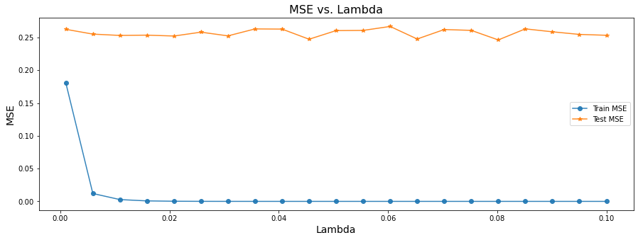

```python
fig, ax = plt.subplots(1,1, figsize=(15,5))
ax.plot(lamda, MSE_train, '-o', label='Train MSE', alpha=0.9)
ax.plot(lamda, MSE_test, '-*', label='Test MSE', alpha=0.9)
ax.set_title('MSE vs. Lambda', fontsize=16)
ax.set_xlabel('Lambda', fontsize=14)
ax.set_ylabel('MSE', fontsize=14)
ax.legend()
```

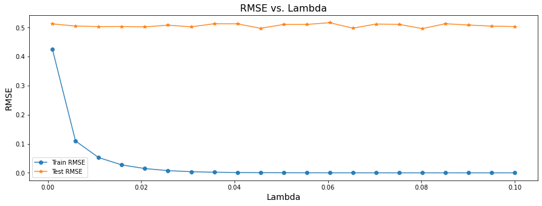

```python
fig, ax = plt.subplots(1,1, figsize=(15,5))
ax.plot(lamda, RMSE_train, '-o', label='Train RMSE', alpha=0.9)
ax.plot(lamda, RMSE_test, '-*', label='Test RMSE', alpha=0.9)
ax.set_title('RMSE vs. Lambda', fontsize=16)
ax.set_xlabel('Lambda', fontsize=14)
ax.set_ylabel('RMSE', fontsize=14)
ax.legend()
```

```python
clf_boosting = GradientBoostingRegressor(max_leaf_nodes = 10, max_depth=4,
                                     random_state=0,
                                  n_estimators=1000, learning_rate=0.08)
clf_boosting = clf_boosting.fit(X_train_scaled,y_train)
```

```python
train_predictions = clf_boosting.predict(X_train_scaled)
mean_squared_error(y_train,train_predictions)
```

```
7.820067079303511e-11
```

```python
test_predictions = clf_boosting.predict(X_test_scaled)
mean_squared_error(y_test,test_predictions)
```

```
0.2592354141843023
```

## 10 d) Produce plot with different shrinkage values on x axis and test set MSE on y axis

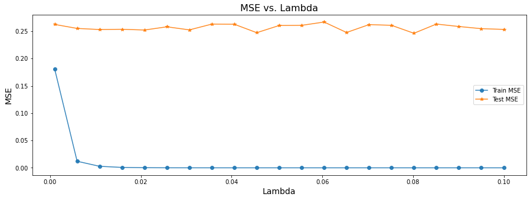

```python
fig, ax = plt.subplots(1,1, figsize=(15,5))
ax.plot(lamda, MSE_train, '-o', label='Train MSE', alpha=0.9)
ax.plot(lamda, MSE_test, '-*', label='Test MSE', alpha=0.9)
ax.set_title('MSE vs. Lambda', fontsize=16)
ax.set_xlabel('Lambda', fontsize=14)
ax.set_ylabel('MSE', fontsize=14)
ax.legend()
```

## 10 e) Compare test MSE of boosting to test MSE from two regression approaches

### Linear Regression

```python
clf = LinearRegression()
clf = clf.fit(X_train_scaled,y_train)
```

```python
train_predictions = clf.predict(X_train_scaled)
```

```python
mean_squared_error(y_train,train_predictions)
```

```
0.3272208991705735
```

```python
test_predictions = clf.predict(X_test_scaled)
```

```python
mean_squared_error(y_test,test_predictions)
```

```
0.44727274005259204
```

### Ridge Regression

```python
reg = linear_model.RidgeCV(alphas=np.logspace(-6, 6, 13),
                          normalize=True,
                          cv=5)
ridge_model = reg.fit(X_train_scaled,y_train)
ridge_model.alpha_
```

```
0.1
```

```python
lamda_cv = ridge_model.alpha_
```

```python
clf = Ridge(alpha=lamda_cv)
ridge_model = clf.fit(X_train_scaled,y_train)
train_predictions = ridge_model.predict(X_train)
test_predictions = ridge_model.predict(X_test)
```

```python
train_predictions = clf.predict(X_train_scaled)
```

```python
mean_squared_error(y_train,train_predictions)
```

```
0.3272645873676484
```

```python
test_predictions = clf.predict(X_test_scaled)
```

```python
mean_squared_error(y_test,test_predictions)
```

```
0.4466745989664213
```

The test MSE for Boosting (0.26) was lower than the test MSE for both linear regression (0.45) and Ridge Regression (0.45)

## 10 f) Which variables appear to be the most important predictors in the boosted model?

```
(0.0, 19.0)
```

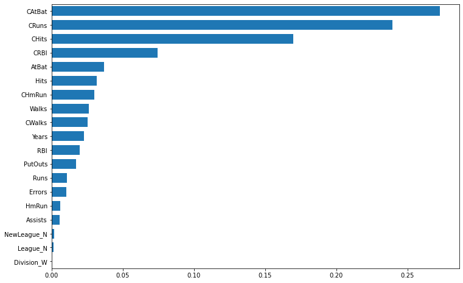

```python
tree_importance_sorted_idx = np.argsort(clf_boosting.feature_importances_)
tree_indices = np.arange(0, len(clf_boosting.feature_importances_)) + 0.5

fig, ax1 = plt.subplots(1, 1, figsize=(12, 8))
ax1.barh(tree_indices,
         clf_boosting.feature_importances_[tree_importance_sorted_idx], height=0.7)
ax1.set_yticklabels(X.columns[tree_importance_sorted_idx])
ax1.set_yticks(tree_indices)
ax1.set_ylim((0, len(clf_boosting.feature_importances_)))
```

Career At-bats, runs and hits all appear to be the most important variables to determine salary. League and Division appear to be the least important to predicting salary.

## 10 g) Apply bagging to the training set. What is test set MSE for this approach?

```python
clf_bagging = RandomForestRegressor(max_leaf_nodes = 10,
                                     random_state=0, max_features = len(X.columns))
```

```python
clf_bagging = clf_bagging.fit(X_train_scaled,y_train)
```

```python
test_predictions = clf_bagging.predict(X_test_scaled)
```

```python
mean_squared_error(y_test,test_predictions)
```

```
0.27180638734527107
```

The test set MSE for bagging was 0.27, slightly higher than the test set MSE for boosting.